# mfinn13_PeerCommentary_imcarlyy_02

2025-02-13

# Introduction

Every Saturday morning, at the same time, a primatologist goes and sits in the forest to listen for titi monkey calls, counting the number of calls they hear in a 2 hour window from 5am to 7am. Based on previous knowledge, she believes that the mean number of calls she will hear in that time is exactly 15. Let X represent the appropriate Poisson random variable of the number of calls heard in each monitoring session.

## 1) What is the probability that she will hear more than 8 calls during any given session?

```r
x <- 9:15 #So, the possibility that she will hear from 9-15 calls.
l = 15 # So she expects to hear on average 15 calls.
probability_result <- dpois(x = x, lambda = l)
probability_result
```

```
## [1] 0.03240717 0.04861075 0.06628739 0.08285923 0.09560681 0.10243587 0.10243587
```

```r
#Comment: You approached this one a little bit differently than I did. It seems like what you did was calculate the individual probabilities that number of calls will be 9, 10, 11... all the way through 15. There are a couple problems with this approach. The first is that the question asks what the probability is that the researcher will hear more than 8 calls, and while the mean is 15, it is possible for her to hear more than 15 calls. The other problem is that your code returns the probabilities individually instead of adding them up. To solve both of these problems, I think you might want to use the ppois() function. What this function does is calculate the probability that a random variable takes on a value that is equal or less than an inputted value. Essentially, this means that if you do ppois(8, 15), where 8 is the number we're stopping at, and 15 is the mean, it will give you the probability that the researcher hears 8 or less calls. Then, you can do 1 minus that probability to give you the probability that she will hear more than 8 calls, because these outcomes are complementary. If that doesn't make sense text me and I'd be happy to try to explain better.
```

## 2) What is the probability that she will hear no calls in a session?

```r
x <- 0 #This is the probability of her hearing 0 calls in a session?
l <- 15 #This is what she, in general, expects to hear on average.
probability_nocalls <- dpois(x = x, lambda = 1)
print(probability_nocalls)
```

```
## [1] 0.3678794
```

```r
#Comment: this is super close to correct! Your using the correct function and everything, I think the only problem is that lambda is set to 1 instead of l (which is equal to 15).
```

## 3) What is the probability that she will hear exactly 3 calls in a session?

```r
x <- 3:3
l <- 15
probability_3calls <- dpois(x = x, lambda = 1)
print(probability_3calls)
```

```
## [1] 0.06131324
```

```r
#Comment: Again, the problem here looks to be that lambda is set to 1 instead of l (which is equal to 15). It should work if you make that change.
```

## 4) Plot the relevant Poisson mass function over the values in range 0 ≤ x ≤ 30.

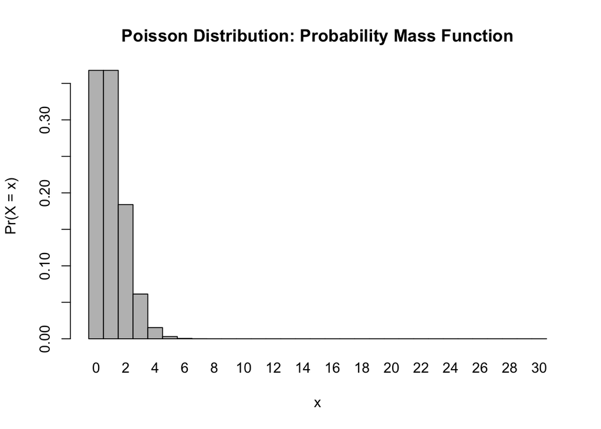

```r
x <- 0:30
l <- 15
prob_0to30 <- dpois(x = x, lambda = 1)
barplot(prob_0to30, names.arg = x, space = 0, xlab = "x", ylab = "Pr(X = x)", main = "Poisson Distribution: Probability Mass Function")
```

```r
#Comment: Again, super close! I think the problem is lambda again. It should be set to l or 15.
```

## 5) Simulate 104 results from this distribution (i.e., 2 years of Saturday monitoring sessions).

```r
n <- 104 #This is equal to my 104 Saturday monitoring sessions. I'm telling R to simulate 104 random results.
l <- 15

simulated_results <- rpois(n = n, lambda = 1)
print(simulated_results)
```

```
##   [1] 0 3 0 0 0 1 2 2 1 0 2 0 2 1 1 1 3 0 0 1 2 1 1 2 0 3 1 1 2 0 0 1 1 0 1 2 0
##  [38] 0 1 1 0 2 0 2 0 0 1 0 2 2 3 3 0 0 0 1 0 0 1 1 0 1 1 0 0 0 1 1 0 1 0 1 0 1
##  [75] 0 2 1 0 0 0 4 1 0 1 1 2 0 2 2 1 2 1 0 2 1 1 2 0 2 0 1 0 1 0
```

```r
#Comment: It's lambda again! Silly lambda. Lambda represents the mean (and because we are in a poisson distribution, it also represents the variance). On line 58, lambda should be set to l or 15.
```